# starter_pack_brazil

The next blocks of code define a simple parameter search to choose a step function.

```python
import logging

# This will be a simple grid search, where we loop through all combinations of parameters in a defined parameter space, run the risk calculation for each combination, and calculate the cost function for each combination.
# We then identify the parameter combination that gives the lowest cost function value.

# First: define the parameter space that we'll be exploring
# For a step function this is a single parameter:
parameter_space = {
    "step": np.arange(0.25, 10.25, 0.5)    # Flood duration is an integer value so we test integer steps
}

# Define a method to create a step impact function
def step_function(step, fun_id=None, name=None):
    return ImpactFunc.from_step_impf(
        intensity=(0, step, 90),   # The intensity values at which the impact function changes.
        mdd=(0, 1),                # The mean damage degree values below and above the step.
        paa=(1, 1),                # The percentage of assets affected below and above the step.
        haz_type='FL',
        impf_id=fun_id,
        intensity_unit="days",
        name=name
    )


# Then, we loop through the parameter space, run the risk calculation, and calculate the cost function for each value.
# We store the results in a list.
def search_for_step_impf(
        entity: Entity,
        impf_id: int,
        step_values: np.ndarray,
        obs_target: float):
    # Suppress logging from a couple of climada modules which can be very verbose when running many calculations in a loop
    logging.getLogger("climada.engine.impact_calc").setLevel(logging.WARNING)
    logging.getLogger("climada.entity.exposures.base").setLevel(logging.WARNING)

    results = []
    for step in step_values:
        print(f"Running risk calculation for step={step:.2f} ...")

        # Create a new impact function based on the original
        impf_old = entity.impact_funcs.get_func(haz_type='FL', fun_id=impf_id)
        impf_new = step_function(step, fun_id=impf_id, name=impf_old.name)

        # Update the entity object with the new impact function
        entity_new = replace_impact_function(entity, impf_new)

        # Rerun the risk calculation and calculate the cost function as before
        _, modelled_affected = risk_calc(entity_new, haz)
        cost = cost_function(modelled_affected, obs_target)

        # Store the results
        results.append({
            "step": step,
            "cost": cost
        })

    logging.getLogger("climada.engine.impact_calc").setLevel(logging.INFO)
    logging.getLogger("climada.entity.exposures.base").setLevel(logging.INFO)
    return pd.DataFrame(results)


results_affected_df = search_for_step_impf(
    entity=entity_affected,
    impf_id=impf_id_affected,
    step_values=parameter_space["step"],
    obs_target=obs_affected_2024
)
display(results_affected_df)
```

```
Running risk calculation for step=0.25 ...
Running risk calculation for step=0.75 ...
Running risk calculation for step=1.25 ...
Running risk calculation for step=1.75 ...
Running risk calculation for step=2.25 ...
Running risk calculation for step=2.75 ...
Running risk calculation for step=3.25 ...
Running risk calculation for step=3.75 ...
Running risk calculation for step=4.25 ...
Running risk calculation for step=4.75 ...
Running risk calculation for step=5.25 ...
Running risk calculation for step=5.75 ...
Running risk calculation for step=6.25 ...
Running risk calculation for step=6.75 ...
Running risk calculation for step=7.25 ...
Running risk calculation for step=7.75 ...
Running risk calculation for step=8.25 ...
Running risk calculation for step=8.75 ...
Running risk calculation for step=9.25 ...
Running risk calculation for step=9.75 ...
```

|  | step | cost |
| --- | --- | --- |
| 0 | 0.25 | 53.125 |
| 1 | 0.75 | 53.125 |
| 2 | 1.25 | 54.375 |
| 3 | 1.75 | 54.375 |
| 4 | 2.25 | 54.375 |
| 5 | 2.75 | 54.375 |
| 6 | 3.25 | 54.375 |
| 7 | 3.75 | 54.375 |
| 8 | 4.25 | 54.375 |
| 9 | 4.75 | 54.375 |
| 10 | 5.25 | 54.375 |
| 11 | 5.75 | 54.375 |
| 12 | 6.25 | 55.000 |
| 13 | 6.75 | 55.000 |
| 14 | 7.25 | 55.625 |
| 15 | 7.75 | 55.625 |
| 16 | 8.25 | 55.625 |
| 17 | 8.75 | 55.625 |
| 18 | 9.25 | 55.625 |
| 19 | 9.75 | 55.625 |

From this search we can identify the ‘best’ impact function and visualize the results:

```python
# Get the index of the minimum value of 'cost'
def get_best_result(results_df):
    ix_best = results_df['cost'].idxmin()
    best_parameters = results_df.loc[ix_best, :]
    return dict(best_parameters)

best_affected_parameters = get_best_result(results_affected_df)
print(f"Best step value: {best_affected_parameters['step']:.2f} with cost: {best_affected_parameters['cost']:.2f}")
```

```
Best step value: 0.25 with cost: 53.12
```

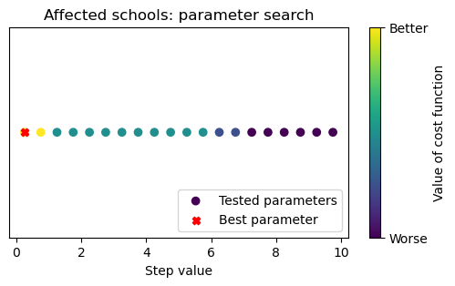

png

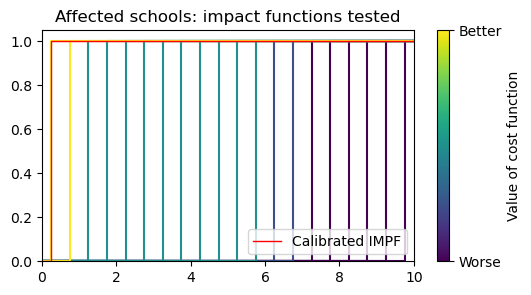

png

```python
from matplotlib.colors import to_hex

# -------------------------------------------
# Methods to visualize the parameter search
# -------------------------------------------

# Helper function for assigning colours to scatter points
def assign_colour_to_costs(results_df):
    # Map the cost to a color according to viridis, where the best score (lowest) is yellow and the worst score (highest) is purple
    # we can do this by normalising the cost to be between 0 and 1, where 0 corresponds to the best 1 corresponds to the worst score
    # In addition, we take the logarithm of the cost to make the differences between smaller costs more visible
    costs = np.log10(results_df['cost'] + 1e-6)  # Add a small value to avoid taking log of zero
    max_score = costs.max()
    min_score = costs.min()
    norm_scores = 1 - (costs - min_score) / (max_score - min_score)
    results_df['colour'] = [to_hex(plt.cm.viridis(score)) for score in norm_scores]
    results_df = results_df.sort_values('cost', ascending=False)  # Also sort the dataframe by cost so that the best scores are plotted on top
    return results_df

# Plot the parameter search space, with points coloured according to the cost function value (yellow = good, purple = bad)
def plot_step_search_space(results_df, title):
    results_df = assign_colour_to_costs(results_df)
    best_step = get_best_result(results_df)
    fig, axis = plt.subplots(figsize=(6, 3))
    axis.scatter(results_df['step'], np.zeros_like(results_df['step']), color=results_df['colour'], label='Tested parameters')
    axis.scatter(best_step['step'], 0, color='red', label='Best parameter', marker='X')
    axis.legend(loc="lower right")

    axis.cbar = plt.colorbar(plt.cm.ScalarMappable(cmap='viridis'), ax=axis)
    axis.cbar.set_label('Value of cost function')
    axis.cbar.set_ticks([0, 1])
    axis.cbar.set_ticklabels(['Worse', 'Better'])

    axis.set_xlabel("Step value")
    axis.set_yticks([])
    axis.set_title(title)
    plt.show()
    plt.close(axis.figure)

# Plot all the impact functions tested in the parameter search, coloured according to the cost function value
def plot_step_search_impfs(results_df, title):
    results_df = assign_colour_to_costs(results_df)
    best_step = get_best_result(results_df)
    fig, axis = plt.subplots(figsize=(6, 3))
    for _, params in results_df.iterrows():
        impf_new = step_function(params['step'])
        axis.plot(impf_new.intensity, impf_new.mdd, color=params['colour'])

    best_impf = step_function(best_step['step'])
    axis.plot(best_impf.intensity, best_impf.mdd, color='red', linewidth=1, label='Calibrated IMPF')
    axis.legend(loc="lower right")

    axis.set_xlim((0, 10))
    axis.set_ylim((0, 1.05))

    axis.cbar = plt.colorbar(plt.cm.ScalarMappable(cmap='viridis'), ax=axis)
    axis.cbar.set_label('Value of cost function')
    axis.cbar.set_ticks([0, 1])
    axis.cbar.set_ticklabels(['Worse', 'Better'])

    axis.set_title(title)
    plt.show()
    plt.close(axis.figure)

plot_step_search_space(results_affected_df, "Affected schools: parameter search")
plot_step_search_impfs(results_affected_df, "Affected schools: impact functions tested")
```

```python
# Recreate the impact calculation with the best parameter values:
impf_best_affected = step_function(best_affected_parameters['step'], fun_id=default_impf_affected.id, name=default_impf_affected.name)

# Update the entity object with the new impact function
entity_affected = replace_impact_function(entity_count, impf_best_affected)

# Rerun the risk calculation and calculate the cost function as before
imp, modelled_affected = risk_calc(entity_affected, haz)
cost = cost_function(modelled_affected, obs_affected_2024)

print(f"\nModelled affected schools: {modelled_affected:.0f}")
print(f"Target affected schools: {obs_affected_2024:.0f}")
print(f"Cost: {cost:.2f}% difference")
```

```
2026-06-11 18:17:03,946 - climada.entity.exposures.base - INFO - Exposures matching centroids already found for FL
2026-06-11 18:17:03,950 - climada.engine.impact_calc - INFO - Calculating impact for 610 assets (>0) and 1 events.

Modelled affected schools: 75
Target affected schools: 160
Cost: 53.12% difference
```

### 7.4.3 Discussion: optimized affected schools

The selected impact function for affected schools tells us a few things:

- No matter what threshold we choose, we can’t model more than 75 affected schools. This is the number of schools that experience any amount of flooding.
- We are therefore underestimating school impacts by about 50%
- This is an issue with the input data: the Exposures data and the loss observations must disagree in some way. Since both contain information on ‘affected schools’ this is likely to be either about what a school is, or what counts as ‘affected’

Why don’t lower flood duration step thresholds push up the impacts? We can see that the threshold of 0.25 gives the same result as 0.75. This is because the hazard measures flood duration in *integer* days. That is, the lowest positive flood duration is 1 day. Any threshold below this will give the same result.

So for now we can’t improve on this. Future work need to repeat this analysis on a different, complete dataset of schools in Porto Alegre.

### 7.4.4 A note on the economic value of schools

This discrepancy in school dataset will cause issues in the calibration: if we can’t model the number of schools affected, it’s likely that we’ll have errors in the loss calculations.

We have attempted to mitigate this a little by choosing a high economic value for an average school – we give each one a value of 2.5 mn USD, which is at the upper end of the data that we have seen for rebuilding schools in Rio Grande do Sul. By choosing this high value we are partially compensating for the low number of schools in our affected Exposure dataset, and we think this will improve the loss modelling in the absence of further data.

## 7.5 Economic loss curve calibration

Now we look at calibrating a loss curve for economic costs. The goal here is to reproduce the reported losses to schools.

In this calibration we want to adjust an existing flood loss curve. There are a lot of ways to approach this: here we will apply scalings along the x- and y-axis to stretch the first-guess function (capping a cap at 100% loss). Other approaches might translate along the x-axis instead of stretching, or might look at ways to change the shape of the function.

### 7.5.1 First-guess analysis

Our Entity file has a first-guess impact function for economic losses. This is what we’ll be improving on:

```python
# Calculate uncalibrated losses
imp_losses, modelled_loss = risk_calc(entity_usd, haz)  # No need to change the impact function since the Entity file is set up to use the loss curve by deafult
cost = cost_function(modelled_loss, obs_loss_2024)
default_impf_loss = entity_usd.impact_funcs.get_func(haz_type='FL', fun_id=impf_id_loss)

default_impf_loss.plot()
print(f"\nModelled losses: {modelled_loss:,.0f} USD")
print(f"Target losses: {obs_loss_2024:,.0f} USD")
print(f"Cost: {cost:.2f}% difference")
```

```
2026-06-11 18:17:03,998 - climada.entity.exposures.base - INFO - Exposures matching centroids already found for FL
2026-06-11 18:17:04,014 - climada.engine.impact_calc - INFO - Calculating impact for 610 assets (>0) and 1 events.

Modelled losses: 45,750,000 USD
Target losses: 121,867,740 USD
Cost: 62.46% difference
```

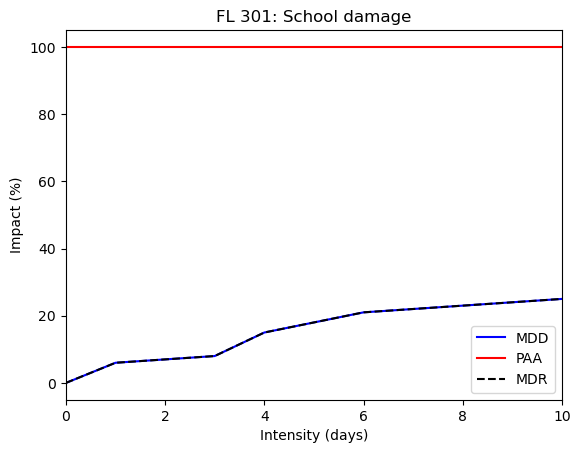

png

#### 7.5.1.1 Discussion: first-guess losses

Given that there is a single loss observation, there are a lot of ways this can be accomplished. Therefore we will need to think about what is realistic.

### 7.5.2 Economic loss: parameter search

The next blocks of code define the parameter search:

```python
import logging

# This will be a simple grid search, where we loop through all combinations of parameters in a defined parameter space, run the risk calculation for each combination, and calculate the cost function for each combination.
# We then identify the parameter combination that gives the lowest cost function value.

# First: define the parameter space that we'll be exploring
# We now use two parameters:

parameter_space = {
    # The function's maximum intensity, above which there is no change in loss. Determines scaling along the x-axis
    "max_intensity": np.arange(0.25, 80.1, 0.75),
    # The function's maximum % damage. Determines scaling along the y-axis so that the function
    "max_damage": np.arange(0.5, 1.21, 0.015),
}


# Define a method that scales an impact function
def scale_impf(impf, max_damage, max_intensity):
    impf_new = copy.deepcopy(impf)   # Make a copy of the impact function to adjust
    x_scale = max_intensity / impf.intensity.max()
    impf_new.intensity = impf_new.intensity * x_scale
    y_scale = max_damage / impf.mdd.max()
    impf_new.mdd = impf_new.mdd * y_scale
    impf_new.mdd = np.clip(impf_new.mdd, 0, 1)   # Ensure that the damage fraction stays between 0 and 1
    return impf_new


def search_for_loss_impf(
        entity: Entity,
        impf_id: int,
        param_space: dict,
        obs_target: pd.Series
    ):
    # Suppress logging from a couple of climada modules which can be very verbose when running many calculations in a loop
    logging.getLogger("climada.engine.impact_calc").setLevel(logging.WARNING)
    logging.getLogger("climada.entity.exposures.base").setLevel(logging.WARNING)

    results = []
    for max_damage in param_space["max_damage"]:
        print(f"Running risk calculations for max_damage={max_damage:.3f} with {len(param_space['max_intensity'])} max_intensity values...")
        for max_intensity in param_space["max_intensity"]:
            # Create a new impact function based on the original
            impf_loss = entity.impact_funcs.get_func(haz_type='FL', fun_id=impf_id)
            impf_new = scale_impf(impf_loss, max_damage, max_intensity)

            # Update the entity object with the new impact function
            entity_new = replace_impact_function(entity, impf_new)

            # Rerun the risk calculation and calculate the cost function as before
            _, modelled_stats = risk_calc(entity_new, haz)
            cost = cost_function(modelled_stats, obs_target)

            # Store the results
            results.append({
                "max_damage": max_damage,
                "max_intensity": max_intensity,
                "cost": cost
            })

    logging.getLogger("climada.engine.impact_calc").setLevel(logging.INFO)
    logging.getLogger("climada.entity.exposures.base").setLevel(logging.INFO)

    return pd.DataFrame(results)

results_loss_df = search_for_loss_impf(
    entity=entity_usd,
    impf_id=impf_id_loss,
    param_space=parameter_space,
    obs_target=obs_loss_2024
)
display(results_loss_df.sort_values('cost').head(10))
```

```
Running risk calculations for max_damage=0.500 with 107 max_intensity values...
Running risk calculations for max_damage=0.515 with 107 max_intensity values...
Running risk calculations for max_damage=0.530 with 107 max_intensity values...
Running risk calculations for max_damage=0.545 with 107 max_intensity values...
Running risk calculations for max_damage=0.560 with 107 max_intensity values...
Running risk calculations for max_damage=0.575 with 107 max_intensity values...
Running risk calculations for max_damage=0.590 with 107 max_intensity values...
Running risk calculations for max_damage=0.605 with 107 max_intensity values...
Running risk calculations for max_damage=0.620 with 107 max_intensity values...
Running risk calculations for max_damage=0.635 with 107 max_intensity values...
Running risk calculations for max_damage=0.650 with 107 max_intensity values...
Running risk calculations for max_damage=0.665 with 107 max_intensity values...
Running risk calculations for max_damage=0.680 with 107 max_intensity values...
Running risk calculations for max_damage=0.695 with 107 max_intensity values...
Running risk calculations for max_damage=0.710 with 107 max_intensity values...
Running risk calculations for max_damage=0.725 with 107 max_intensity values...
Running risk calculations for max_damage=0.740 with 107 max_intensity values...
Running risk calculations for max_damage=0.755 with 107 max_intensity values...
Running risk calculations for max_damage=0.770 with 107 max_intensity values...
Running risk calculations for max_damage=0.785 with 107 max_intensity values...
Running risk calculations for max_damage=0.800 with 107 max_intensity values...
Running risk calculations for max_damage=0.815 with 107 max_intensity values...
Running risk calculations for max_damage=0.830 with 107 max_intensity values...
Running risk calculations for max_damage=0.845 with 107 max_intensity values...
Running risk calculations for max_damage=0.860 with 107 max_intensity values...
Running risk calculations for max_damage=0.875 with 107 max_intensity values...
Running risk calculations for max_damage=0.890 with 107 max_intensity values...
Running risk calculations for max_damage=0.905 with 107 max_intensity values...
Running risk calculations for max_damage=0.920 with 107 max_intensity values...
Running risk calculations for max_damage=0.935 with 107 max_intensity values...
Running risk calculations for max_damage=0.950 with 107 max_intensity values...
Running risk calculations for max_damage=0.965 with 107 max_intensity values...
Running risk calculations for max_damage=0.980 with 107 max_intensity values...
Running risk calculations for max_damage=0.995 with 107 max_intensity values...
Running risk calculations for max_damage=1.010 with 107 max_intensity values...
Running risk calculations for max_damage=1.025 with 107 max_intensity values...
Running risk calculations for max_damage=1.040 with 107 max_intensity values...
Running risk calculations for max_damage=1.055 with 107 max_intensity values...
Running risk calculations for max_damage=1.070 with 107 max_intensity values...
Running risk calculations for max_damage=1.085 with 107 max_intensity values...
Running risk calculations for max_damage=1.100 with 107 max_intensity values...
Running risk calculations for max_damage=1.115 with 107 max_intensity values...
Running risk calculations for max_damage=1.130 with 107 max_intensity values...
Running risk calculations for max_damage=1.145 with 107 max_intensity values...
Running risk calculations for max_damage=1.160 with 107 max_intensity values...
Running risk calculations for max_damage=1.175 with 107 max_intensity values...
Running risk calculations for max_damage=1.190 with 107 max_intensity values...
Running risk calculations for max_damage=1.205 with 107 max_intensity values...
```

|  | max_damage | max_intensity | cost |
| --- | --- | --- | --- |
| 1188 | 0.665 | 8.50 | 0.002699 |
| 2086 | 0.785 | 40.00 | 0.002880 |
| 2853 | 0.890 | 53.50 | 0.003994 |
| 1071 | 0.650 | 1.00 | 0.005957 |
| 1070 | 0.650 | 0.25 | 0.005957 |
| 2416 | 0.830 | 46.75 | 0.031145 |
| 3400 | 0.965 | 62.50 | 0.044491 |
| 1533 | 0.710 | 26.50 | 0.045406 |
| 1307 | 0.680 | 17.50 | 0.046165 |
| 3838 | 1.025 | 70.00 | 0.053827 |

```python
# ------------------------------------
# Visualize the parameter search results, now in two dimensions
# ------------------------------------

def plot_loss_search_space(results_df, best_params):
    # Map the cost to a color according to viridis, where the best score (lowest) is yellow and the worst score (highest) is purple
    # we can do this by normalising the cost to be between 0 and 1, where 0 corresponds to the best 1 corresponds to the worst score
    results_df = assign_colour_to_costs(results_df)
    fig, axis = plt.subplots(figsize=(6, 3))
    axis.scatter(results_df['max_intensity'], results_df['max_damage'], color=results_df['colour'])
    axis.scatter(best_params['max_intensity'], best_params['max_damage'], color='red', label='Best parameter combination', marker='X')
    axis.set_xlabel("Max intensity")
    axis.set_ylabel("Max damage")
    axis.set_title("Parameter search results")

def plot_loss_search_impfs(results_df, best_params, impf_orig):
    results_df = assign_colour_to_costs(results_df)
    fig, axis = plt.subplots(figsize=(6, 3))
    for _, params in results_df.iterrows():
        impf_new = scale_impf(impf_orig, params['max_damage'], params['max_intensity'])
        axis.plot(impf_new.intensity, impf_new.mdd, color=params['colour'])

    best_impf = scale_impf(impf_orig, best_params['max_damage'], best_params['max_intensity'])
    axis.plot(best_impf.intensity, best_impf.mdd, color='red', linewidth=1, label='Optimized IMPF')

    axis.legend(loc="lower right")

    axis.cbar = plt.colorbar(plt.cm.ScalarMappable(cmap='viridis'), ax=axis)
    axis.cbar.set_label('Value of cost function')
    axis.cbar.set_ticks([0, 1])
    axis.cbar.set_ticklabels(['Worse', 'Better'])

    axis.set_xlim((0, 80))
    axis.set_ylim((0, 1.05))
    axis.set_xlabel("Intensity (days)")
    axis.set_ylabel("Mean damage degree")
    axis.set_title("Impact functions tested")

    plt.show()
    plt.close(axis.figure)

best_loss_parameters = get_best_result(results_loss_df)
print(f"Best parameter combination:")
print(f"max_intensity: {best_loss_parameters['max_intensity']:.2f}")
print(f"max_damage: {best_loss_parameters['max_damage']:.2f}")
print(f"Cost: {best_loss_parameters['cost']:.2f}")

impf_orig = entity_usd.impact_funcs.get_func(haz_type='FL', fun_id=impf_id_loss)
plot_loss_search_space(results_loss_df, best_loss_parameters)
plot_loss_search_impfs(results_loss_df, best_loss_parameters, impf_orig)
```

```
Best parameter combination:
max_intensity: 8.50
max_damage: 0.67
Cost: 0.00
```

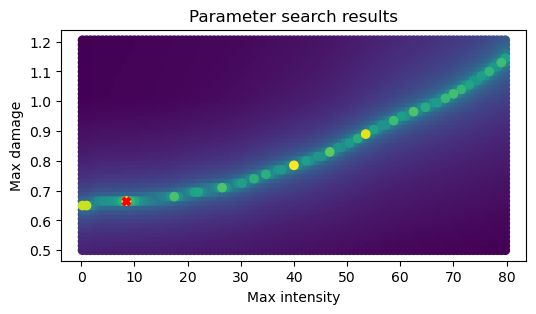

png

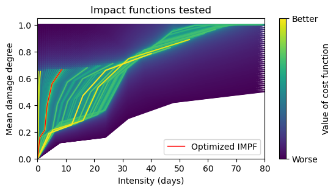

png

```python
# Recreate the impact calculation with the best parameter values:
impf_best_loss = scale_impf(impf_orig, best_loss_parameters['max_damage'], best_loss_parameters['max_intensity'])

# Update the entity object with the new impact function
entity_loss = replace_impact_function(entity_usd, impf_best_loss)

# Rerun the risk calculation and calculate the cost function as before
imp_optimized, modelled_loss = risk_calc(entity_loss, haz)
cost = cost_function(modelled_loss, obs_loss_2024)

impf_best_loss.plot()
print(f"\nModelled losses: {modelled_loss:,.0f} USD")
print(f"Target losses: {obs_loss_2024:,.0f} USD")
print(f"Cost: {cost:.2f}% difference")
```

```
2026-06-11 18:19:09,563 - climada.entity.exposures.base - INFO - Exposures matching centroids already found for FL
2026-06-11 18:19:09,575 - climada.engine.impact_calc - INFO - Calculating impact for 610 assets (>0) and 1 events.

Modelled losses: 121,871,029 USD
Target losses: 121,867,740 USD
Cost: 0.00% difference
```

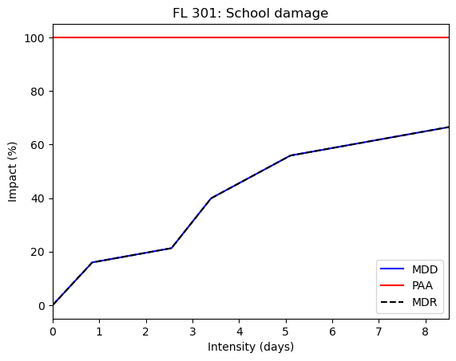

png

### 7.5.3 Discussion: economic loss

The algorithm identified a whole family of potential impact functions. In the plot of the parameter space, we see a curve of near perfect fits crossing the space, shaded in yellow.

This is unsurprising: given that we are calibrating to a *single* target observation, we would expect that, for every value of `max_intensity` there is a value of `max_damage` that can reproduce the observations: you only need one degree of freedom to match one observation.

This leaves us with a challenge: without further observations we can’t decide which point in the parameter space is most suitable. The function chosen by the algorithm is almost at random: it’s whichever point in the parameter space happens to be closest to the ‘true’ curve. (Change the `parameter_space` bounds to see this in action: you may get an optimal curve that maxes out at 2 days, or at 80 days.)

We need more information to make a good choice. Without that we have to use expert judgement.

If we choose a curve to the right of the parameter space, we get a function where losses increase slowly with flood duration, and reach their maximum after 60 days or more.

### 7.5.4 Choice of calibrated function

We can therefore specify some subjective choices, based on our experience of flood losses.

For example, we could decide that maximum impact should be above 70% (`max_damage > 0.7`), since we know several schools were completely rebuilt. Looking at the earlier charts this means that the flood impacts will increase with up to 25 or more days of flood duration: let’s set it to be max out at under 30 (`max_intensity < 30`).

You can adjust these as you like and see how it affects the impact function.

### 7.5.5 Conclusion

There is more work to be done before this impact function can be used with confidence.

The calibration here is a particular challenge: it is hard to calibrate to a single observation, and it is even harder when your Exposure data doesn’t align well with the observations you’re trying to reproduce. This final impact function was chosen from a large family of equally plausible functions, given what we know. Further research would improve the analysis greatly: either by extending the school exposure data, aligning definitions of ‘affected’ between the input data sources, or finding further observations, either from other events, or splitting the 2024 data into Bairros to compare individual locations.

```python
filtered_results = results_loss_df[
    (results_loss_df['max_damage'] > 0.7) &
    (results_loss_df['max_intensity'] < 30)
]

best_filtered_params = get_best_result(filtered_results)
print(f"Best parameters among filtered results:")
print(f"Max damage: {best_filtered_params['max_damage']:.2f}")
print(f"Max intensity: {best_filtered_params['max_intensity']:.2f}")

impf_chosen = scale_impf(
    impf=impf_orig,
    max_damage=best_filtered_params['max_damage'],
    max_intensity=best_filtered_params['max_intensity']
)
impf_chosen.plot()

# Update the entity object with the new impact function
entity_usd_chosen = replace_impact_function(entity_usd, impf_chosen)

# Rerun the risk calculation and calculate the cost function as before
imp_chosen, modelled_stats = risk_calc(entity_usd_chosen, haz)
cost = cost_function(modelled_stats, obs_loss_2024)
print(f"\nModelled losses: {modelled_stats:,.0f} USD")
print(f"Target losses: {obs_loss_2024:,.0f} USD")
print(f"Cost: {cost:.2f}% difference")
```

```
Best parameters among filtered results:
Max damage: 0.71
Max intensity: 26.50
2026-06-11 18:19:11,250 - climada.entity.exposures.base - INFO - Exposures matching centroids already found for FL
2026-06-11 18:19:11,261 - climada.engine.impact_calc - INFO - Calculating impact for 610 assets (>0) and 1 events.

Modelled losses: 121,923,075 USD
Target losses: 121,867,740 USD
Cost: 0.05% difference
```

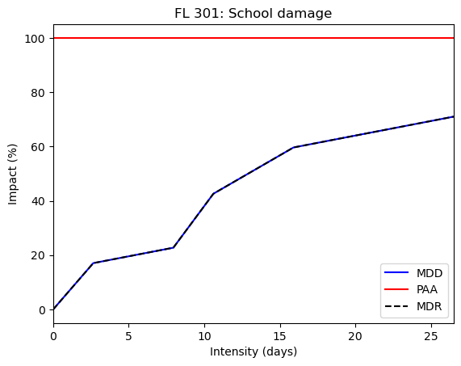

png

```python
# Plot the two impact functions
fig, axis = plt.subplots(figsize=(8, 4))
axis.plot(impf_best_loss.intensity, impf_best_loss.mdd, color='blue', label='Optimized')
axis.plot(impf_chosen.intensity, impf_chosen.mdd, color='green', label='Alternative')
axis.set_xlabel("Hazard intensity (days)")
axis.set_ylabel("Impact (%)")
axis.set_xlim((0, 50))
axis.legend(loc="upper left")
axis.set_title("Comparison of impact functions")
```

```
Text(0.5, 1.0, 'Comparison of impact functions')
```

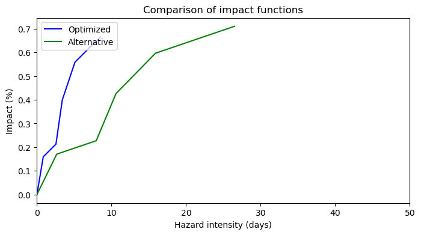

png

## 7.6 Write calibrated Entity file

This is a manual process. The code below copies the Entity file to the data/entity_files_calibrated folder and prints out the chosen impact functions.

You can then update the impact functions in the Excel file by copying the table over.

```python
import shutil

entity_final = copy.deepcopy(entity_usd)

# Swap in the new impact functions for loss, affected, and destroyed
new_impfset = ImpactFuncSet([impf_chosen, impf_best_affected])
old_impf_ids = [impf.id for impf in entity_final.impact_funcs.get_func(haz_type='FL')]
new_impf_ids = [impf.id for impf in new_impfset.get_func(haz_type='FL')]
assert np.array_equal(old_impf_ids, new_impf_ids), "The new impact function IDs do not match the old ones"
entity_final.impact_funcs = new_impfset

# Copy over original file and update with calibrated impact functions
shutil.copy(entity_filepath, calibrated_entity_filepath)

# Open the impact_functions sheet in the Excel file and overwrite with the new impact functions
impf_export_list = []
for impf in [impf_chosen, impf_best_affected]:
    impf_df = pd.DataFrame({
        "impact_fun_id": impf.id,
        "intensity_m": impf.intensity,
        "mdd": impf.mdd,
        "paa": impf.paa,
        "peril_id": "FL",
        "name": impf.name,
        "intensity_unit": "meter"
    })
    impf_export_list.append(impf_df)

impf_export_df = pd.concat(impf_export_list, ignore_index=True)

print(f"Final impact functions. Copy into Excel file to overwrite the original impact functions:")
display(impf_export_df.style.format({
    "impact_fun_id": "{:d}",
    "intensity_m": "{:.3f}",
    "mdd": "{:.3f}",
    "paa": "{:.3f}"
}))
```

```
Final impact functions. Copy into Excel file to overwrite the original impact functions:
```

|  | impact_fun_id | intensity_m | mdd | paa | peril_id | name | intensity_unit |
| --- | --- | --- | --- | --- | --- | --- | --- |
| 0 | 301 | 0.000 | 0.000 | 1.000 | FL | School damage | meter |
| 1 | 301 | 2.650 | 0.170 | 1.000 | FL | School damage | meter |
| 2 | 301 | 5.300 | 0.199 | 1.000 | FL | School damage | meter |
| 3 | 301 | 7.950 | 0.227 | 1.000 | FL | School damage | meter |
| 4 | 301 | 10.600 | 0.426 | 1.000 | FL | School damage | meter |
| 5 | 301 | 13.250 | 0.511 | 1.000 | FL | School damage | meter |
| 6 | 301 | 15.900 | 0.596 | 1.000 | FL | School damage | meter |
| 7 | 301 | 18.550 | 0.625 | 1.000 | FL | School damage | meter |
| 8 | 301 | 21.200 | 0.653 | 1.000 | FL | School damage | meter |
| 9 | 301 | 23.850 | 0.682 | 1.000 | FL | School damage | meter |
| 10 | 301 | 26.500 | 0.710 | 1.000 | FL | School damage | meter |
| 11 | 302 | 0.000 | 0.000 | 1.000 | FL | School affected | meter |
| 12 | 302 | 0.250 | 0.000 | 1.000 | FL | School affected | meter |
| 13 | 302 | 0.250 | 1.000 | 1.000 | FL | School affected | meter |
| 14 | 302 | 90.000 | 1.000 | 1.000 | FL | School affected | meter |

# 8 Cost-benefit calculations

In this notebook we will:

- Load the components of present-day and future risk
- Create a `CostBenefit` object and run the calculations that apply adaptation measures
- Explore the output statistics

## 8.1 Read in Data

```python
from pathlib import Path

# -----------------------------------------------------
# Set up paths to data
# -----------------------------------------------------

ENTITY_DIR = "../data/entity_files_adaptation/"
ENTITY_FILE = "Porto_Alegre_BRAZIL_Entity_Floods_Schools_calibrated_measures.xlsx"
entity_path = Path(ENTITY_DIR) / ENTITY_FILE

# Here we use the JRC return period flood data
HAZARD_DIR = "../data/hazard/"
HAZARD_RETURN_PERIODS = [10, 20, 50, 100, 200, 500]
HAZARD_FILES = [f"PortoAlegre_RP{rp}_depth.tif" for rp in HAZARD_RETURN_PERIODS]
haz_paths = [Path(HAZARD_DIR) / f for f in HAZARD_FILES]

# -----------------------------------------------------
# Set constants
# -----------------------------------------------------

YEAR_PRESENT = 2025
YEAR_FUTURE = 2050

# Path to file with information on changes to return period frequencies
# Columns: scenario, year, return_period_present, return_period_future
FUTURE_HAZARD_FREQUENCIES_PATH = "../data/hazard/porto_alegre_rp_mapping_2025_2050.csv"
```

### 8.1.1 Create present-day and future Entity objects

As in previous examples we don’t read in a future Entity file. Instead create it from the present-day Entity by applying an annual growth rate to the assets and changing the reference year, keeping everything else the same.

```python
import copy
from climada.entity import Entity, MeasureSet

# -----------------------------------------------------
# Create present and future Entity objects
# -----------------------------------------------------

entity_present = Entity.from_excel(entity_path)
entity_future = copy.deepcopy(entity_present)

entity_present.exposures.ref_year = YEAR_PRESENT
entity_present.exposures.value_unit = "USD"
entity_present.exposures.description = f"{YEAR_PRESENT} schools economic exposure"

entity_future.exposures.ref_year = YEAR_FUTURE
entity_future.exposures.value_unit = "USD"
entity_future.exposures.description = f"{YEAR_FUTURE} schools economic exposure"

# -----------------------------------------------------
# Scale future exposures for projected economic growth
# -----------------------------------------------------

# Set this figure to something realistic!
# Average annual projected growth rate of the economy during the study period
# (not inflation rate: all currency is in 2025 USD)
ECONOMIC_GROWTH_RATE = 0.02

n_years = YEAR_FUTURE - YEAR_PRESENT
growth = (1 + ECONOMIC_GROWTH_RATE) ** n_years

new_gdf = entity_future.exposures.gdf
new_gdf["value"] = new_gdf["value"] * growth
entity_future.exposures.set_gdf(new_gdf)

print(f"Total value of exposures in {YEAR_PRESENT}: {entity_present.exposures.value.sum():,.2f} USD")
print(f"Total value of exposures in {YEAR_FUTURE}: {entity_future.exposures.value.sum():,.2f} USD")
print(f"Total proportional growth of exposures from {YEAR_PRESENT} to {YEAR_FUTURE}: {growth:,.2f}")
```

```
Total value of exposures in 2025: 305,000,000.00 USD
Total value of exposures in 2050: 500,384,828.31 USD
Total proportional growth of exposures from 2025 to 2050: 1.64
```

### 8.1.2 Create present-day and future hazard objects

As in previous examples, we create future hazard information by adjusting the frequencies of present-day hazard footprints so that they occur more frequently.

```python
# -----------------------------------------------------
# Read hazard data
# -----------------------------------------------------

import numpy as np
import pandas as pd
from climada.hazard import Hazard

# Read the hazard data

# Since we're reading hazard data from .tif files, we need to provide some additional metadata, including a frequency for each event
# As shown in the Hazard notebook, we have to convert return period frequencies to event frequencies:
def event_frequency_from_return_periods(return_periods):
    rp_rev = copy.deepcopy(return_periods)[::-1]  # Reverse the list so that it's in order of increasing frequency (decreasing return period)
    exceedance_frequency = np.array([1/rp for rp in rp_rev])
    event_frequency = np.diff(np.concatenate([[0], exceedance_frequency]))
    event_frequency = event_frequency[::-1]  # Reverse the frequencies so that they match the order of the events in the hazard file again
    return event_frequency

event_frequency_present = event_frequency_from_return_periods(HAZARD_RETURN_PERIODS)

# Read in the hazard data
haz_present = Hazard.from_raster(
    files_intensity = haz_paths,
    attrs={
        'unit': 'm',
        'event_name': [f'Return period {rp}' for rp in HAZARD_RETURN_PERIODS],     # We can optionally name the events
        'frequency': event_frequency_present                                         # For probabilistic analyses we have to define the frequency of each event
    },
    haz_type='FL'
)


# -----------------------------------------------------
# Adjust event frequencies to create future hazard
# -----------------------------------------------------

future_rps_df = pd.read_csv(Path(FUTURE_HAZARD_FREQUENCIES_PATH))
assert future_rps_df["historical_return_period"].tolist() == HAZARD_RETURN_PERIODS, "The return periods in the future frequencies file do not match the return periods of the hazard data"

future_rps = future_rps_df["future_return_period_2050"]
event_frequency_future = event_frequency_from_return_periods(future_rps)

haz_future = copy.deepcopy(haz_present)
haz_future.event_name = [f'Return period {rp}' for rp in future_rps]
haz_future.frequency = event_frequency_future
```

```
2026-06-30 18:51:26,159 - climada.util.coordinates - INFO - Reading ../data/hazard/PortoAlegre_RP10_depth.tif
2026-06-30 18:51:26,555 - climada.util.coordinates - INFO - Reading ../data/hazard/PortoAlegre_RP10_depth.tif
2026-06-30 18:51:26,565 - climada.util.coordinates - INFO - Reading ../data/hazard/PortoAlegre_RP20_depth.tif
2026-06-30 18:51:26,575 - climada.util.coordinates - INFO - Reading ../data/hazard/PortoAlegre_RP50_depth.tif
2026-06-30 18:51:26,583 - climada.util.coordinates - INFO - Reading ../data/hazard/PortoAlegre_RP100_depth.tif
2026-06-30 18:51:26,593 - climada.util.coordinates - INFO - Reading ../data/hazard/PortoAlegre_RP200_depth.tif
2026-06-30 18:51:26,600 - climada.util.coordinates - INFO - Reading ../data/hazard/PortoAlegre_RP500_depth.tif
```

```python
# -----------------------------------------------------
# Assign hazard centroids to exposure points
# -----------------------------------------------------

entity_present.exposures.assign_centroids(haz_present)
entity_future.exposures.assign_centroids(haz_future)
```

```
2026-06-30 18:51:26,630 - climada.entity.exposures.base - INFO - Matching 122 exposures with 142155 centroids.
2026-06-30 18:51:26,781 - climada.util.coordinates - INFO - No exact centroid match found. Reprojecting coordinates to nearest neighbor closer than the threshold = 0.0016666666666651508 degree
2026-06-30 18:51:26,827 - climada.entity.exposures.base - INFO - Matching 122 exposures with 142155 centroids.
2026-06-30 18:51:26,903 - climada.util.coordinates - INFO - No exact centroid match found. Reprojecting coordinates to nearest neighbor closer than the threshold = 0.0016666666666651508 degree
```

## 8.2 Cost-Benefit calculation

We initialize a `CostBenefit` object and run the calculation with its `calc` method. This takes four key inputs: the present-day hazard, the present-day Entity, the future hazard and the future Entity.

To calculate the cost-benefit for a single Measure, CLIMADA performs four risk calculations:

- Present-day unadapted risk
- Present-day adapted risk
- Future unadapted risk
- Future adapted risk

The *benefit* of a Measure is the sum of the impacts it prevents over the study time period. Each measure is assumed to be implemented in the first year of the analysis period (Note: this will be customizable in CLIMADA Version 7). The model calculates the benefits the Measure provides in the present-day and future climates (by subtracting the adapted risk from the unadapted risk). These benefits are interpolated from the start year to the end year, adjusted to their ‘net present value’ using the Discount Rates, and then summed to give a total benefit over the study period (see the `imp_time_depen` parameter for some control over how this interpolation is performed).

When it finishes the cost-benefit calculation prints statistics for each Measure and for all measures combined.

**Notes: negative values**

- Negative costs are allowed (when the Measure generates an income that exceeds its implementation costs over the studied time period), and will give a negative cost-benefit. You’ll have to be careful while interpreting this.
- Negative benefits are allowed (when the Measure makes things worse), and will also give negative cost-benefits. If you see this and didn’t expect to, check how you specified the Measure, negative benefits shouldn’t show up unless you specify that the Measure makes things worse.

**Notes: which data are read from which Entity file**

- If the future hazard or future entity is not specified, it is assumed not to change over time, and the present-day hazard or Entity is substituted
- Measures and Impact Functions should be kept the same in both the present and future Entities.
  - Be careful: the analysis won’t necessary fail if this is not the case: CLIMADA allows changes to the Impact Functions (this become part of the ‘Economic Development’ component of the change in risk), Changes to the Measures will throw an error when the measures have different names, and will otherwise become part of the avoided risk/benefits component of the analysis.
- Discount rates are read from the present-day Entity

```python
from climada.engine import CostBenefit
from climada.engine.cost_benefit import risk_aai_agg

costben = CostBenefit()
costben.calc(
    haz_present,
    entity_present,
    haz_future=haz_future,
    ent_future=entity_future,
    assign_centroids=False
)
```

```
2026-06-30 18:51:26,982 - climada.engine.impact_calc - INFO - Calculating impact for 610 assets (>0) and 6 events.
2026-06-30 18:51:26,997 - climada.engine.impact_calc - INFO - Calculating impact for 610 assets (>0) and 6 events.
2026-06-30 18:51:27,020 - climada.engine.impact_calc - INFO - Calculating impact for 585 assets (>0) and 6 events.
2026-06-30 18:51:27,174 - climada.engine.impact_calc - INFO - Calculating impact for 610 assets (>0) and 6 events.
2026-06-30 18:51:27,182 - climada.engine.impact_calc - INFO - Calculating impact for 610 assets (>0) and 6 events.
2026-06-30 18:51:27,187 - climada.engine.impact_calc - INFO - Calculating impact for 610 assets (>0) and 6 events.
2026-06-30 18:51:27,194 - climada.engine.impact_calc - INFO - Calculating impact for 610 assets (>0) and 6 events.
2026-06-30 18:51:27,204 - climada.engine.impact_calc - INFO - Calculating impact for 585 assets (>0) and 6 events.
2026-06-30 18:51:27,326 - climada.engine.impact_calc - INFO - Calculating impact for 610 assets (>0) and 6 events.
2026-06-30 18:51:27,332 - climada.engine.impact_calc - INFO - Calculating impact for 610 assets (>0) and 6 events.
2026-06-30 18:51:27,336 - climada.engine.cost_benefit - INFO - Computing cost benefit from years 2025 to 2050.

Measure                 Cost (USD m)    Benefit (USD m)    Benefit/Cost
--------------------  --------------  -----------------  --------------
River dredging               789.562           195.782         0.247963
Rebuilding levees            161.171           257.866         1.59995
Early warning system           1.5              32.0348       21.3566

--------------------  ---------  -------
Total climate risk:    320.348   (USD m)
Average annual risk:    19.0853  (USD m)
Residual risk:        -165.334   (USD m)
--------------------  ---------  -------
Net Present Values
```

From this statistical summary we can already learn a few things:

- The levees measure has the highest benefit, but the early warning system has the highest benefit to cost ratio
- Dredging has a benefit to cost ratio less than one. This means that *based on losses to schools alone* the measures prevent less damage than they cost to implement. This is to be expected: losses from schools made up only a small portion of the total flood impacts. A complete study would include benefits from other modelled asset types as well, including homes and businesses.
- The sum of the losses prevented by the measures (the total benefits) exceed the total risk over the study period, resulting in a negative residual risk. This is because some impacts are ‘prevented’ twice: e.g. the levees prevent losses that are also prevented by the early warning system.

## 8.3 Visualizations

### 8.3.1 Cost-benefit graph

The cost-benefit graph is a bar chart displaying the above statistics. Each bar represents a modelled adaptation measure:

- The bar width shows the Measure’s benefit (the net present value of losses prevented over the study period). Wider bars have larger benefits.
- The bar height shows the Measure’s benefit to cost ratio. Taller bars are better value for money. Bars with a benefit to cost ratio greater than 1 are considered to have a positive return on investment.

Two red points are marked on the x-axis to help understand the scale of benefits. The ‘AAI’ shows the average modelled loss in one year over the analysis period. The ‘Tot risk’ shows the total accumulated losses over the analysis period. If the bars extend beyond this second point, it means that the summed benefits of the Measures prevent more than the total unadapted loss, as discussed above.

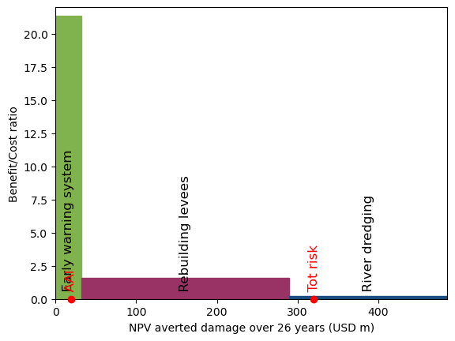

png

```python
_ = costben.plot_cost_benefit()
```

In this plot we see:

- The early warning systems are the tallest bar, showing the clearest positive return on investment. They have a benefit to cost ratio greater than one (even when evaluated against the single asset type of schools). Since there are many benefits to early warning systems that are not quantified in this analysis (e.g. preventing loss of life, emotional impacts of loss, long-term economic consequences), it seems that this is already a good idea – assuming that the prevented losses are accurate in the Measure.
- The levees have the widest bar and therefore prevent the most losses. The benefit to cost ratio is also greater than one. Since this is a huge investment, we would need to look at the losses to homes and businesses that are prevented before we can quantify the total benefits. (Note: and make sure the upkeep costs are included.)

## 8.4 Benefits by return period

It can be useful to understand *what kind of event* your Measures protect against. Some measures may only pretect against less intense events; some may be most beneficial at long return periods.

To do this we can use the `CostBenefit.plot_event_view` method, which shows the losses prevented at different modelled return periods. During the CostBenefit calculation, CLIMADA saved exceedance frequency curves for adapted and unadapted climates, meaning the benefits of measures can be estimated for different severities of event.

The plot has a bar for each requested return period. A black outline shows the unadapted risk, and filled bars are overlaid showing how much risk each measure offsets. Again, when the total stacked amount is larger than the black outline, the total benefit is larger than the modelled impacts.

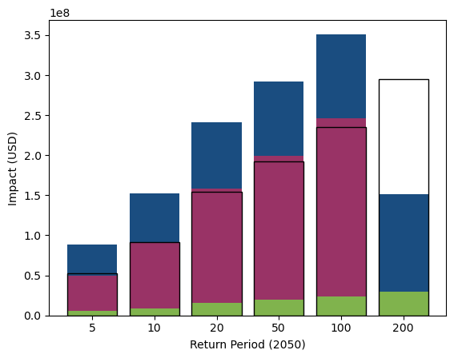

png

```python
# Plot benefits by return period

ax = costben.plot_event_view(return_per=future_rps)
```

This plot tells us:

We can see from this plot where the potential gap in adaptation is: floods that exceed the protection levels of the levees.

This can drive additional modelling questions that could support decision-makers. We could look at additional Measures that answer the following questions:

- What would the cost and cost-benefit be of higher levees? Are they a feasible and cost-effective investment?
- Can we design an insurance product that covers this remaining loss?

### 8.4.1 Waterfall plot

We can show the prevented loss on a waterfall plot with the `CostBenefit.plot_arrow_averted` method. It adds an arrow to the future risk column of the plot, showing what proportion of the risk is prevented by the summed Measures’ benefits.

In this case that is 100% of the risk:

```python
# Create a waterfall plot
ax = costben.plot_waterfall(
       haz_present, entity_present, haz_future, entity_future
    )

# Add an arrow showing averted risk
costben.plot_arrow_averted(
    axis=ax,
    in_meas_names=entity_present.measures.get_names()['FL'],
    accumulate=True,
    combine=False,
    risk_func=risk_aai_agg,
    disc_rates=None,
    imp_time_depen=1,
)
```

```
2026-06-30 18:51:27,843 - climada.engine.impact_calc - INFO - Calculating impact for 610 assets (>0) and 6 events.
2026-06-30 18:51:27,850 - climada.engine.impact_calc - INFO - Calculating impact for 610 assets (>0) and 6 events.
2026-06-30 18:51:27,868 - climada.engine.cost_benefit - INFO - Risk at 2025: 5.609e+06
2026-06-30 18:51:27,873 - climada.engine.impact_calc - INFO - Calculating impact for 610 assets (>0) and 6 events.
2026-06-30 18:51:27,878 - climada.engine.cost_benefit - INFO - Risk with development at 2050: 9.201e+06
2026-06-30 18:51:27,879 - climada.engine.cost_benefit - INFO - Risk with development and climate change at 2050: 1.909e+07
```

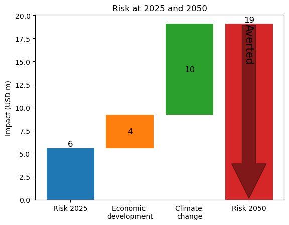

png

### 8.4.2 Extensions to this notebook

Note: this is a first version of the cost-benefit notebook. It should give you enough information to build and run your own cost-benefit analyses.

There are still a few topics to look at in more depth: - the effects of discount rates on an analysis - the effects of time dependency on an analysis - mapping benefits - working with multiple asset types - insurance as a Measure - other properties of the CostBenefit class

There are still a few improvements to make to the data: - use of projected socioeconomic change information to estimate future school assets - more scientifically-grounded estimations of the changes of flood return periods under climate change - include upkeep costs in the Measures